# HW2

Выполнила: Растворова А.

Загружаем библиотеку.

```r
library('BoolNet')
```

Construct a Boolean network from these statements and save it to a file. Load the network into BoolNet using the function and visualize its wiring.

```r
network = loadNetwork('network.txt', bodySeparator = ',', lowercaseGenes = F, symbolic = F)
print(network)
```

```
Boolean network with 9 genes

Involved genes:
MBF SBF YOX1 HCM1 YHP1 SFF ACE2 SWI5 CLN3

Transition functions:
MBF = CLN3
SBF = ((CLN3 | MBF) & (!YOX1 & !YHP1 | !YOX1 & YHP1 | YOX1 & !YHP1))
YOX1 = (MBF & SBF)
HCM1 = (MBF & SBF)
YHP1 = (MBF | SBF)
SFF = (SBF & HCM1)
ACE2 = SFF
SWI5 = SFF
CLN3 = (SWI5 & ACE2 & (!YOX1 & YHP1| YOX1 & !YHP1 | !YOX1 & !YHP1))
```

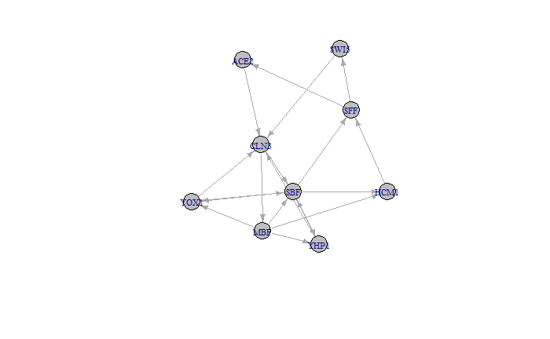

```r
plotNetworkWiring(network)
```

### #2

Now perform a Markov chain simulation of the network with 500 iterations.

```r
simulation = markovSimulation(network, numIterations = 500)
simulation$reachedStates
```

| MBF | SBF | YOX1 | HCM1 | YHP1 | SFF | ACE2 | SWI5 | CLN3 | Probability |
| --- | --- | --- | --- | --- | --- | --- | --- | --- | --- |
| 0 | 0 | 0 | 0 | 0 | 0 | 0 | 0 | 0 | 0.1972656 |
| 1 | 1 | 0 | 0 | 0 | 0 | 0 | 0 | 0 | 0.1406250 |
| 0 | 1 | 1 | 1 | 1 | 0 | 0 | 0 | 0 | 0.1113281 |
| 0 | 0 | 0 | 0 | 1 | 1 | 0 | 0 | 0 | 0.1992188 |
| 0 | 0 | 0 | 0 | 0 | 0 | 1 | 1 | 0 | 0.0703125 |
| 0 | 0 | 0 | 0 | 0 | 0 | 0 | 0 | 1 | 0.2812500 |

**How many states have a non-zero probability of being reached after these 500 iterations?** После 500 итераций было получено 6 состояний с ненулевой вероятностью.

### #3

Perform an exhaustive synchronous attractor search.

```r
attractor = getAttractors(network,
                          type = 'synchronous',
                          method = 'exhaustive',
                          returnTable = T)
attractor
```

```
Attractor 1 is a simple attractor consisting of 1 state(s) and has a basin of 101 state(s):

 |--<--------|
 V           |
 000000000   |
 V           |
 |-->--------|


Genes are encoded in the following order: MBF SBF YOX1 HCM1 YHP1 SFF ACE2 SWI5 CLN3

Attractor 2 is a simple attractor consisting of 5 state(s) and has a basin of 411 state(s):

 |--<--------|
 V           |
 110000000   |
 011110000   |
 000011000   |
 000000110   |
 000000001   |
 V           |
 |-->--------|


Genes are encoded in the following order: MBF SBF YOX1 HCM1 YHP1 SFF ACE2 SWI5 CLN3
```

**How many attractors are found? How many of them are steady states (consisting of only one state), and how many of them are multi-state cycles?** Первых из двух получившихся является steady, второй - multi-state.  
**How do the attractors relate to the results Exercise 2?** Состояния аттракторов, полученные в #3, идентичны состояниям, полученным в #2.

Visualize the basins of attraction using *plotStateGraph()*.

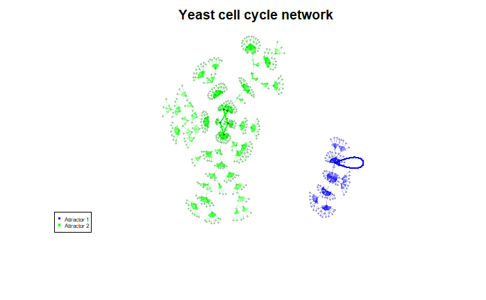

```r
plotStateGraph(attractor, main = "Yeast cell cycle network")
```

Visualize the state changes of the attractors.

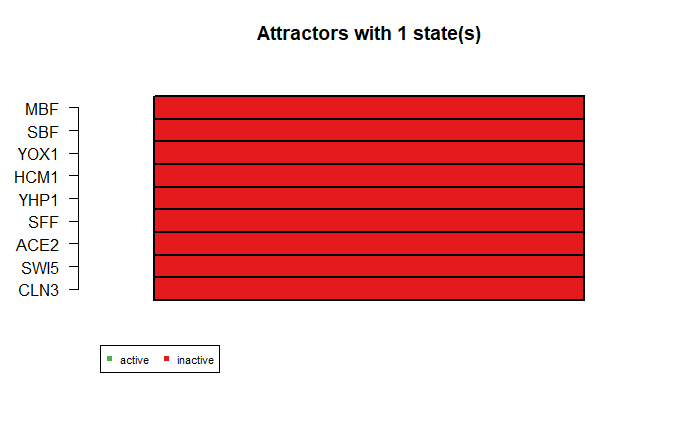

```
$`1`
     Attr1.1
MBF        0
SBF        0
YOX1       0
HCM1       0
YHP1       0
SFF        0
ACE2       0
SWI5       0
CLN3       0

$`5`
     Attr2.1 Attr2.2 Attr2.3 Attr2.4 Attr2.5
MBF        1       0       0       0       0
SBF        1       1       0       0       0
YOX1       0       1       0       0       0
HCM1       0       1       0       0       0
YHP1       0       1       1       0       0
SFF        0       0       1       0       0
ACE2       0       0       0       1       0
SWI5       0       0       0       1       0
CLN3       0       0       0       0       1
```

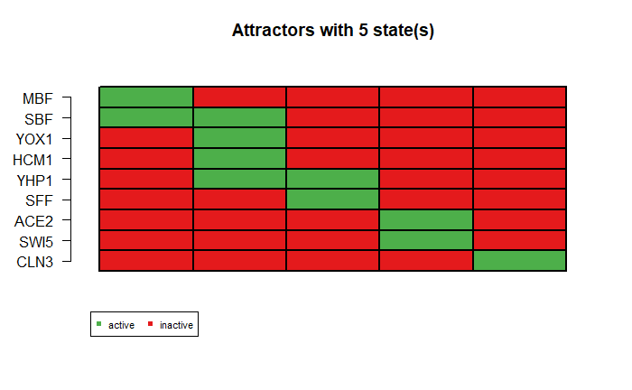

```r
plotAttractors(attractor)
```

Which synchronous attractor is reached if all genes are expressed initially?

```r
attractor = getAttractors(network,
                          type = 'synchronous',
                          startStates = list(rep(1, length(network$genes))))
attractor
```

```
Attractor 1 is a simple attractor consisting of 5 state(s) and has a basin of 8 state(s):

 |--<--------|
 V           |
 110000000   |
 011110000   |
 000011000   |
 000000110   |
 000000001   |
 V           |
 |-->--------|


Genes are encoded in the following order: MBF SBF YOX1 HCM1 YHP1 SFF ACE2 SWI5 CLN3
```

Which states are traversed from the initial state to the attractor (use *getPathToAttractor()* or *plotSequence()*)?

```
     1 2 3 4 5 6 7 8
CLN3 1 0 0 1 0 0 0 0
SWI5 1 1 1 0 0 0 0 1
ACE2 1 1 1 0 0 0 0 1
SFF  1 1 0 0 0 0 1 0
YHP1 1 1 1 0 0 1 1 0
HCM1 1 1 0 0 0 1 0 0
YOX1 1 1 0 0 0 1 0 0
SBF  1 0 0 0 1 1 0 0
MBF  1 1 0 0 1 0 0 0
```

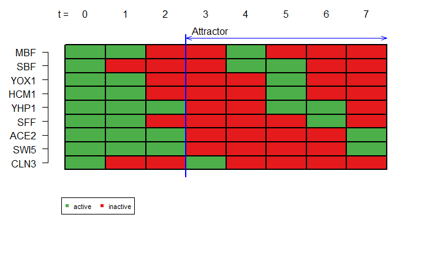

```r
plotSequence(network=network,
             startState=rep(1, length(network$genes)),
             includeAttractorStates="all")
```

```r
sequence = getPathToAttractor(network,
                              state=rep(1, 9),
                              includeAttractorStates="all")
print(sequence)
```

| MBF | SBF | YOX1 | HCM1 | YHP1 | SFF | ACE2 | SWI5 | CLN3 |
| --- | --- | --- | --- | --- | --- | --- | --- | --- |
| 1 | 1 | 1 | 1 | 1 | 1 | 1 | 1 | 1 |
| 1 | 0 | 1 | 1 | 1 | 1 | 1 | 1 | 0 |
| 0 | 0 | 0 | 0 | 1 | 0 | 1 | 1 | 0 |
| 0 | 0 | 0 | 0 | 0 | 0 | 0 | 0 | 1 |
| 1 | 1 | 0 | 0 | 0 | 0 | 0 | 0 | 0 |
| 0 | 1 | 1 | 1 | 1 | 0 | 0 | 0 | 0 |
| 0 | 0 | 0 | 0 | 1 | 1 | 0 | 0 | 0 |
| 0 | 0 | 0 | 0 | 0 | 0 | 1 | 1 | 0 |

```
IGRAPH dd6bbd4 DN-- 8 8 --
+ attr: name (v/c), width (e/n), curved (e/n)
+ edges from dd6bbd4 (vertex names):
[1] 1->2 2->3 3->4 4->5 5->6 6->7 7->8 8->4
```

[figure not shown]

```r
plotSequence(sequence=sequence, mode="graph")
```

**How do the attractors differ from the exhaustive synchronous attractor search if you perform an asynchronous attractor search?**Только один steady.

```r
attractor = getAttractors(network, type = 'asynchronous')
attractor
```

```
Attractor 1 is a simple attractor consisting of 1 state(s):

 |--<--------|
 V           |
 000000000   |
 V           |
 |-->--------|


Genes are encoded in the following order: MBF SBF YOX1 HCM1 YHP1 SFF ACE2 SWI5 CLN3
```

### #4

Create a copy of your network with MBF overexpressed and CLN3 knocked out.

```r
network = fixGenes(network,
                   fixIndices = c(1, 9),
                   values = c(1, 0))
attractor = getAttractors(network,
                          type = 'synchronous',
                          method = 'exhaustive')
attractor
```

```
Attractor 1 is a simple attractor consisting of 4 state(s) and has a basin of 128 state(s):

 |--<--------|
 V           |
 110010000   |
 111110000   |
 101111000   |
 100010110   |
 V           |
 |-->--------|


Genes are encoded in the following order: MBF SBF YOX1 HCM1 YHP1 SFF ACE2 SWI5 CLN3
```

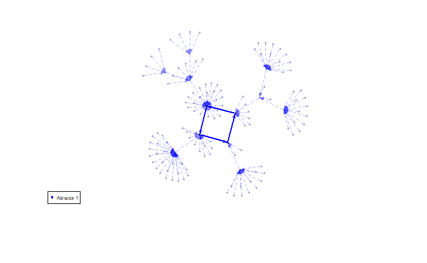

```r
plotStateGraph(attractor)
```

**How do the synchronous attractors of this network differ from the original network?** Один multi-state с 4 состояниям. В первой сети multi-state имел 5 других состояний.